**Machine Learning for Mechanical Engineering**  
**Homework 06 - Solution**

Instructor: Prof. Seungchul Lee  
http://iai.postech.ac.kr/  
Industrial AI Lab at POSTECH

# Problem 1

In our class, we used the sklearn-embedded functions for kNN. Here, you are asked to write your own function for the kNN regressor.

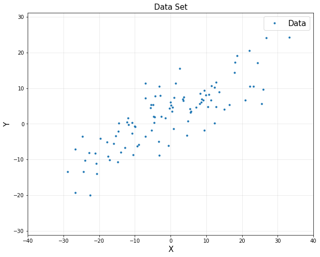

```python
import numpy as np
import matplotlib.pyplot as plt
%matplotlib inline

N = 100
w1 = 0.5
w0 = 2
x = np.random.normal(0, 15, N).reshape(-1,1)
y = w1*x + w0 + 5*np.random.normal(0, 1, N).reshape(-1,1)

plt.figure(figsize = (10, 8))
plt.title('Data Set', fontsize = 15)
plt.plot(x, y, '.', label = 'Data')
plt.xlabel('X', fontsize = 15)
plt.ylabel('Y', fontsize = 15)
plt.legend(fontsize = 15)
plt.axis('equal')
plt.axis([-40, 40, -30, 30])
plt.grid(alpha = 0.3)
plt.show()
```

```python
# here is your function for KNNReg
#
```

```python
# here is your code for plotting
#
```

# Solution 1

In our class, we used the sklearn-embedded functions for kNN. Here, you are asked to write your own function for the kNN regressor.

```python
# K = 1
data = np.hstack([x, y])
xp = np.linspace(-30, 30, 100).reshape(-1, 1)
yp = []

for i in range(len(xp)):

    dist_and_index = []

    for j, pts in enumerate(data):
        dist = 0
        dist = np.sqrt(np.sum((np.subtract(pts[:-1], xp[i]))**2))

        dist_and_index.append((dist, j))

    sort_dist_and_index = sorted(dist_and_index)

    knn_dist_and_index = sort_dist_and_index[:1]

    knn_labels = [data[j][1] for dist, j in knn_dist_and_index]

    knn_avg = np.mean(knn_labels)

    yp.append(knn_avg)
```

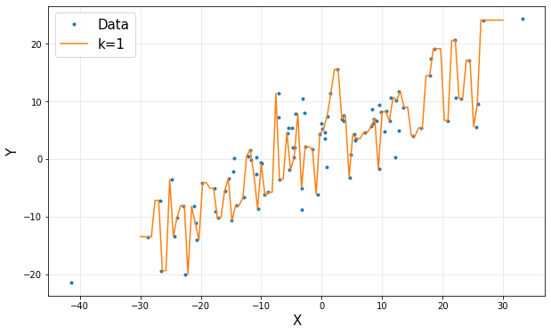

```python
plt.figure(figsize=(10, 6))
plt.plot(x, y, '.', label = 'Data')
plt.plot(xp, yp, label = 'k=1')
plt.legend(fontsize = 15)
plt.grid(alpha = 0.3)
plt.xlabel('X', fontsize = 15)
plt.ylabel('Y', fontsize = 15)
plt.show()
```

```python
# K=10
xp = np.linspace(-30, 30, 100).reshape(-1, 1)
yp = []

for i in range(len(xp)):

    dist_and_index = []

    for j, pts in enumerate(data):
        dist = 0
        dist = np.sqrt(np.sum((np.subtract(pts[:-1], xp[i]))**2))

        dist_and_index.append((dist, j))

    sort_dist_and_index = sorted(dist_and_index)

    knn_dist_and_index = sort_dist_and_index[:10]

    knn_labels = [data[j][1] for dist, j in knn_dist_and_index]

    knn_avg = np.mean(knn_labels)

    yp.append(knn_avg)
```

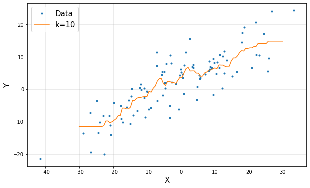

```python
plt.figure(figsize=(10, 6))
plt.plot(x, y, '.', label = 'Data')
plt.plot(xp, yp, label = 'k=10')
plt.legend(fontsize = 15)
plt.grid(alpha = 0.3)
plt.xlabel('X', fontsize = 15)
plt.ylabel('Y', fontsize = 15)
plt.show()
```

# Problem 2

In our class, we used the sklearn-embedded functions for kNN. Here, you are asked to write your own function for the kNN classification.

```
(-1.6485567132500083,
 1.6461080824254721,
 -1.6493412223280284,
 1.6485583368982042)
```

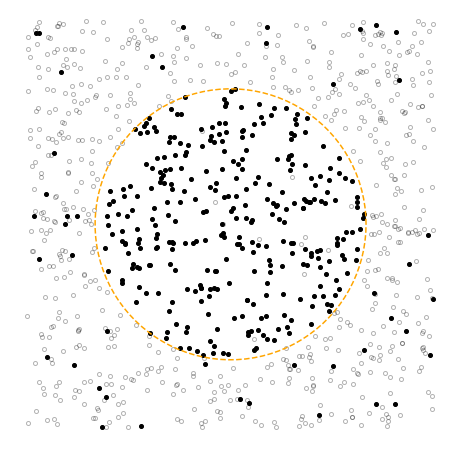

```python
m = 1000
X = -1.5 + 3*np.random.uniform(size = (m,2))

y = np.zeros([m,1])
for i in range(m):
    if np.linalg.norm(X[i,:], 2) <= 1:
        if np.random.uniform() < 0.05:
            y[i] = 0
        else:
            y[i] = 1
    else:
        if np.random.uniform() < 0.05:
            y[i] = 1
        else:
            y[i] = 0

C1 = np.where(y == 1)[0]
C0 = np.where(y == 0)[0]

theta = np.linspace(0, 2*np.pi, 100)

plt.figure(figsize = (8,8))
plt.plot(X[C1,0], X[C1,1], 'o', label = 'C1', markerfacecolor = "k", markeredgecolor = 'k', markersize = 4)
plt.plot(X[C0,0], X[C0,1], 'o', label = 'C0', markerfacecolor = "None", alpha = 0.3, markeredgecolor = 'k', markersize = 4)
plt.plot(np.cos(theta), np.sin(theta), '--', color = 'orange')
plt.axis([-1.5, 1.5, -1.5, 1.5])
plt.axis('equal')
plt.axis('off')
```

```python
# write down your code
```

```python
#write down your code
```

# Solution 2

```
(-1.6441062668554611,
 1.6457936620650138,
 -1.6484630859889466,
 1.6464547945701078)
```

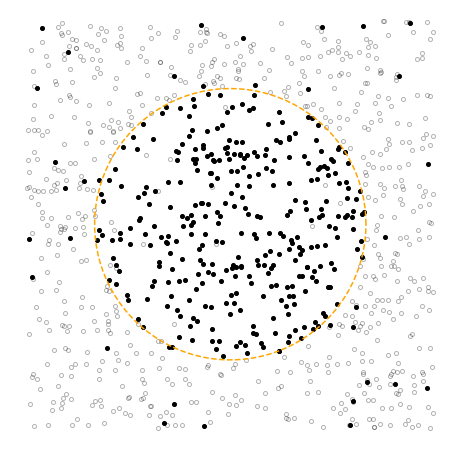

```python
m = 1000
X = -1.5 + 3*np.random.uniform(size = (m,2))

y = np.zeros([m,1])
for i in range(m):
    if np.linalg.norm(X[i,:], 2) <= 1:
        if np.random.uniform() < 0.05:
            y[i] = 0
        else:
            y[i] = 1
    else:
        if np.random.uniform() < 0.05:
            y[i] = 1
        else:
            y[i] = 0

C1 = np.where(y == 1)[0]
C0 = np.where(y == 0)[0]

theta = np.linspace(0, 2*np.pi, 100)

plt.figure(figsize = (8,8))
plt.plot(X[C1,0], X[C1,1], 'o', label = 'C1', markerfacecolor = "k", markeredgecolor = 'k', markersize = 4)
plt.plot(X[C0,0], X[C0,1], 'o', label = 'C0', markerfacecolor = "None", alpha = 0.3, markeredgecolor = 'k', markersize = 4)
plt.plot(np.cos(theta), np.sin(theta), '--', color = 'orange')
plt.axis([-1.5, 1.5, -1.5, 1.5])
plt.axis('equal')
plt.axis('off')
```

```python
from collections import Counter
res = 0.01
[X1gr, X2gr] = np.meshgrid(np.arange(-1.5,1.5,res), np.arange(-1.5,1.5,res))
Xp = np.hstack([X1gr.reshape(-1,1), X2gr.reshape(-1,1)]) ##
for i in range(len(Xp)):
    t = np.sqrt(np.sum((np.subtract(Xp[i], X))**2, axis=1)).reshape(-1, 1) ## Euclidian distance
    q = np.hstack([t, y])
    sort_p = sorted(q.tolist()) ## Sort the distance
    knnCLF = sort_p[:1] # Select the top highest dataset
    knnCLF = np.array(knnCLF)
    knnCLF_label = knnCLF[:,1] ##
    yp.append(Counter(knnCLF_label).most_common(1)[0][0])
```

```python
yp = np.array(yp)
inCircle = np.where(yp == 1)[0]
```

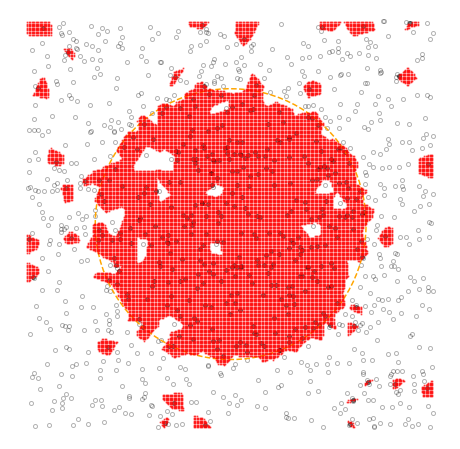

```python
plt.figure(figsize = (8, 8))
plt.plot(X[C1,0], X[C1,1], 'o', label = 'C1', markerfacecolor = "k", alpha = 0.5, markeredgecolor = 'k', markersize = 4)
plt.plot(X[C0,0], X[C0,1], 'o', label = 'C0', markerfacecolor = "None", alpha = 0.3, markeredgecolor='k', markersize = 4)
plt.plot(np.cos(theta), np.sin(theta), '--', color = 'orange')
plt.plot(Xp[inCircle][:,0], Xp[inCircle][:,1], 's', alpha = 0.5, color = 'r', markersize = 1)
plt.axis([-1.5, 1.5, -1.5, 1.5])
plt.axis('equal')
plt.axis('off')
plt.show()
```

```python
yp = []
for i in range(len(Xp)):
    t = np.sqrt(np.sum((np.subtract(Xp[i], X))**2, axis=1)).reshape(-1, 1)
    q = np.hstack([t, y])
    sort_p = sorted(q.tolist())
    knnCLF = sort_p[:10]
    knnCLF = np.array(knnCLF)
    knnCLF_label = knnCLF[:,1]
    yp.append(Counter(knnCLF_label).most_common(1)[0][0])
```

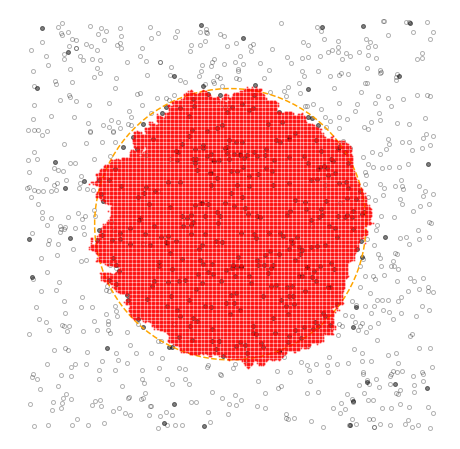

```python
yp = np.array(yp)
inCircle = np.where(yp == 1)[0]
plt.figure(figsize = (8, 8))
plt.plot(X[C1,0], X[C1,1], 'o', label = 'C1', markerfacecolor = "k", alpha = 0.5, markeredgecolor = 'k', markersize = 4)
plt.plot(X[C0,0], X[C0,1], 'o', label = 'C0', markerfacecolor = "None", alpha = 0.3, markeredgecolor='k', markersize = 4)
plt.plot(np.cos(theta), np.sin(theta), '--', color = 'orange')
plt.plot(Xp[inCircle][:,0], Xp[inCircle][:,1], 's', alpha = 0.5, color = 'r', markersize = 1)
plt.axis([-1.5, 1.5, -1.5, 1.5])
plt.axis('equal')
plt.axis('off')
plt.show()
```

# Problem 3

Look at the following training set for a decision tree that classifies names as either location or person names:

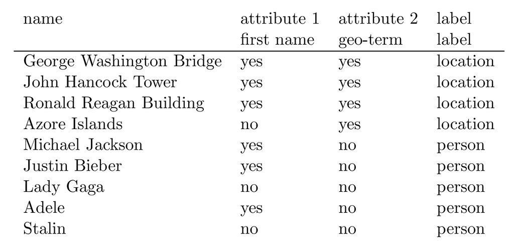

1) Calculate the disorder of attribute 1.

2) Calculate the disorder of attribute 2.

3) Which attribute is more useful, attribute 1 or attribute 2 ? and Why?

$$\begin{align*} D & = -\frac{l}{T} \log_2 \frac{l}{T} - \frac{p}{T} \log_2 \frac{p}{T} \qquad \text{where }\; l: \text{location}, \; p: \text{person},\; T: \text{Total}\\ \\ \end{align*} $$$$Q(\text{test}) = \sum D(\text{set}) \times \frac{\text{# of samples in set}}{\text{# of samples in all sets}}$$

1) Calculate disorder of attribute 1.

$$\begin{align*} D_{\text{attribute1 yes}} & = -\frac{3}{6} \log_2 \frac{3}{6} - \frac{3}{6} \log_2 \frac{3}{6} = 1\\ \\ D_{\text{attribute1 no}} & = -\frac{1}{3} \log_2 \frac{1}{3} - \frac{2}{3} \log_2 \frac{2}{3} = 0.9183 \end{align*} $$

2) Calculate disorder of attribute 2.

$$\begin{align*} D_{\text{attribute2 yes}} & = -\frac{4}{4} \log_2 \frac{4}{4} - \frac{0}{4} \log_2 \frac{0}{4} = 0\\ \\ D_{\text{attribute2 no}} & = -\frac{0}{5} \log_2 \frac{0}{5} - \frac{5}{5} \log_2 \frac{5}{5} = 0 \end{align*} $$

3) Which attribute is more useful, attribute 1 or attribute 2 Why?

$$ \begin{align*} Q_{\text{attribute1}} &= 1\times\frac{6}{9} + 0.9183\times\frac{3}{9} = 0.973\\ Q_{\text{attribute2}} &= 0\times\frac{4}{9} + 0\times\frac{5}{9} = 0\\\\ Q_{\text{attribute1}} &> Q_{\text{attribute2}}\\\\ \therefore \;&\text{attribute 2 is more useful.} \end{align*} $$

# Problem 3 in PS06

There are data points from four classes in 2 dimensional space. Each data point has its own centroid.

1) Plot the data points on 2D plane and calculate the centroid of each class. (treat as a supervised learning)

```python
import numpy as np
import matplotlib.pyplot as plt
```

```python
data1 = np.array((np.random.normal(0, 0.2, 100), np.random.normal(0.0, 0.4, 100)))
data2 = np.array((np.random.normal(1.2, 0.3, 100), np.random.normal(1.1, 0.7, 100)))
data3 = np.array((np.random.normal(1.6, 0.2, 100), np.random.normal(1.8, 0.7, 100)))
data4 = np.array((np.random.normal(0.3, 0.1, 100), np.random.normal(0.5, 0.3, 100)))
```

```python
# Write your code here

c1 = [c1x, c1y]
c2 = [c2x, c2y]
c3 = [c3x, c3y]
c3 = [c4x, c4y]
print('centrid 1 : ', c1)
print('centrid 2 : ', c2)
print('centrid 3 : ', c3)
print('centrid 4 : ', c4)

plt.scatter(label ='class 1', c = 'r', s = 1)
plt.scatter(label ='class 2', c = 'b', s = 1)
plt.scatter(label ='class 3', c = 'g', s = 1)
plt.scatter(label ='class 4', c = 'c', s = 1)
plt.scatter( s = 100, c = 'r')
plt.scatter( s = 100, c = 'b')
plt.scatter( s = 100, c = 'g')
plt.scatter( s = 100, c = 'c')
plt.legend()
plt.show()
```

2) Assume that the labels are unknown, and then do k-means clustering on the given data points and compare the centroids of k-means clustering with the above centroids. (set $k = 4$)

```python
#Write down your cod3
```

3) Assume that we do not know the number of partitions $k$. Choose the number of clusters by checking the 'elbow-point' in the cost verses $k$ graph.

```python
#Write down your cod3
```

# Solution 3

```python
import numpy as np
import matplotlib.pyplot as plt
data1 = np.array((np.random.normal(0, 0.2, 100), np.random.normal(0.0, 0.4, 100)))
data2 = np.array((np.random.normal(1.2, 0.3, 100), np.random.normal(1.1, 0.7, 100)))
data3 = np.array((np.random.normal(1.6, 0.2, 100), np.random.normal(1.8, 0.7, 100)))
data4 = np.array((np.random.normal(0.3, 0.1, 100), np.random.normal(0.5, 0.3, 100)))
```

```
centroid 1 :  [-0.005031498254473488, 0.0024705407264053805]
centroid 2 :  [1.192179770919884, 1.0423854906512]
centroid 3 :  [1.584708032654621, 1.9110063970232098]
centroid 4 :  [0.30962812369827875, 0.4883960101437581]
```

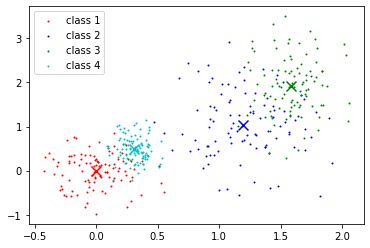

```python
c1x = np.mean(data1[0])
c1y = np.mean(data1[1])
c2x = np.mean(data2[0])
c2y = np.mean(data2[1])
c3x = np.mean(data3[0])
c3y = np.mean(data3[1])
c4x = np.mean(data4[0])
c4y = np.mean(data4[1])

c1 = [c1x, c1y]
c2 = [c2x, c2y]
c3 = [c3x, c3y]
c4 = [c4x, c4y]
print('centroid 1 : ', c1)
print('centroid 2 : ', c2)
print('centroid 3 : ', c3)
print('centroid 4 : ', c4)

plt.scatter(data1[0], data1[1], label ='class 1', c = 'r', s = 1)
plt.scatter(data2[0], data2[1], label ='class 2', c = 'b', s = 1)
plt.scatter(data3[0], data3[1], label ='class 3', c = 'g', s = 1)
plt.scatter(data4[0], data4[1], label ='class 4', c = 'c', s = 1)
plt.scatter(c1[0], c1[1],marker = 'x', s = 100, c = 'r')
plt.scatter(c2[0], c2[1],marker = 'x', s = 100, c = 'b')
plt.scatter(c3[0], c3[1],marker = 'x', s = 100, c = 'g')
plt.scatter(c4[0], c4[1],marker = 'x', s = 100, c = 'c')
plt.legend()
plt.show()
```

```
centroid 1 :  [0.36142770768787047, 0.48726480384409276]
centroid 2 :  [1.480404809242816, 2.2437168855211134]
centroid 3 :  [1.4214501481550679, 1.0899156957468028]
centroid 4 :  [0.03189584783125768, -0.127150940371834]
```

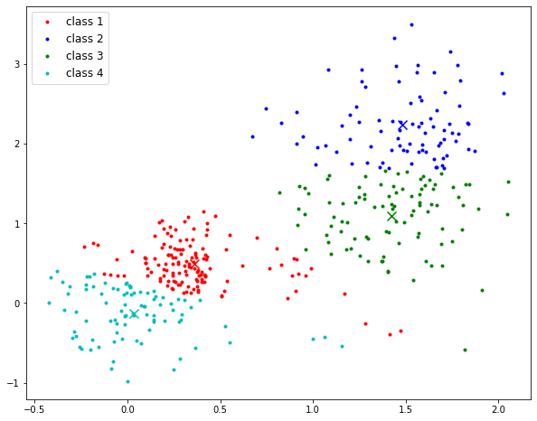

```python
from sklearn.cluster import KMeans

X = np.hstack((data1, data2, data3, data4))
X = np.asmatrix(X)
X = X.T
kmeans = KMeans(n_clusters = 4, random_state = 0)
kmeans.fit(X)


c1x = np.mean(X[kmeans.labels_ == 0,0])
c1y = np.mean(X[kmeans.labels_ == 0,1])
c2x = np.mean(X[kmeans.labels_ == 1,0])
c2y = np.mean(X[kmeans.labels_ == 1,1])
c3x = np.mean(X[kmeans.labels_ == 2,0])
c3y = np.mean(X[kmeans.labels_ == 2,1])
c4x = np.mean(X[kmeans.labels_ == 3,0])
c4y = np.mean(X[kmeans.labels_ == 3,1])

c1 = [c1x, c1y]
c2 = [c2x, c2y]
c3 = [c3x, c3y]
c4 = [c4x, c4y]
print('centroid 1 : ', c1)
print('centroid 2 : ', c2)
print('centroid 3 : ', c3)
print('centroid 4 : ', c4)

plt.figure(figsize = (10,8))
plt.plot(X[kmeans.labels_ == 0,0],X[kmeans.labels_ == 0,1], 'r.', label = 'class 1')
plt.plot(X[kmeans.labels_ == 1,0],X[kmeans.labels_ == 1,1], 'b.', label = 'class 2')
plt.plot(X[kmeans.labels_ == 2,0],X[kmeans.labels_ == 2,1], 'g.', label = 'class 3')
plt.plot(X[kmeans.labels_ == 3,0],X[kmeans.labels_ == 3,1], 'c.', label = 'class 4')
plt.scatter(c1[0], c1[1],marker = 'x', s = 100, c = 'r')
plt.scatter(c2[0], c2[1],marker = 'x', s = 100, c = 'b')
plt.scatter(c3[0], c3[1],marker = 'x', s = 100, c = 'g')
plt.scatter(c4[0], c4[1],marker = 'x', s = 100, c = 'c')
plt.legend(fontsize = 12)
plt.show()
```

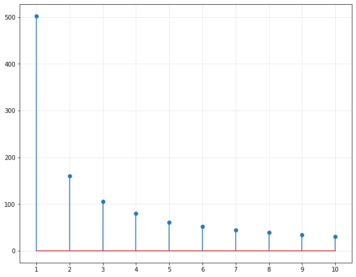

```python
cost = []
for i in range(1,11):
    kmeans = KMeans(n_clusters = i, random_state = 0).fit(X)
    cost.append(abs(kmeans.score(X)))

plt.figure(figsize = (10,8))
plt.stem(range(1,11), cost)
plt.xticks(np.arange(11))
plt.xlim([0.5, 10.5])
plt.grid(alpha = 0.3)
plt.show()
```

# Problem 4 in PS06

In our class, we did [k-means clustering on image colors](https://i-systems.github.io/teaching/ML/iNotes/09_K-means_Clustering.html#5.-Example). In some special cases, we can use k-means clustering for noise reduction in color. This is one of images from Piet Mondrian.

[Download data](https://www.dropbox.com/s/18g3twjkibh1tii/Piet%20Mondrian.jpg?dl=1)

1) Do the k-means clustering on this image. (Choose appropriate $k$ that you think)

[figure not shown]

```python
img = plt.imread('./image_files/Piet Mondrian.jpg')
plt.axis('off')
plt.imshow(img)
plt.show()
```

2) How many clusters are needed for this image? Check the cost as $k$ increases. Then paint it with the centroid colors.

```python
# write your code here
#
```

# Solution 4

```python
from sklearn.cluster import KMeans

m = img.shape[0]
n = img.shape[1]
X = img.reshape(m*n, 3)

k = 6
kmeans = KMeans(n_clusters = k, random_state = 0)
kmeans.fit(X)
```

```
KMeans(algorithm='auto', copy_x=True, init='k-means++', max_iter=300,
    n_clusters=6, n_init=10, n_jobs=None, precompute_distances='auto',
    random_state=0, tol=0.0001, verbose=0)
```

```python
X_clustered = np.zeros([m*n,3])

for i in range(k):
    X_clustered[np.where(kmeans.labels_ == i)] = kmeans.cluster_centers_[i]
```

[figure not shown]

```python
plt.figure(figsize = (8,8))
plt.imshow(X_clustered.reshape(m, n, 3).astype('uint8'))
plt.axis('off')
plt.show()
```

```
1
2
3
4
5
6
7
```

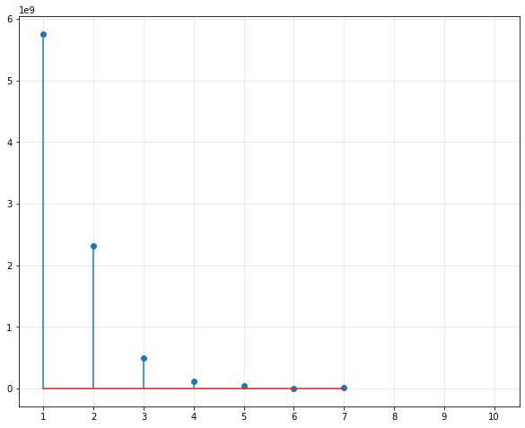

```python
cost = []
for i in range(1, 8):
    kmeans = KMeans(n_clusters = i, random_state = 0).fit(X)
    cost.append(abs(kmeans.score(X_clustered)))
    print(i)

plt.figure(figsize = (10,8))
plt.stem(range(1,8), cost)
plt.xticks(np.arange(11))
plt.xlim([0.5, 10.5])
plt.grid(alpha = 0.3)
plt.show()
```